# AA_BINARY

## Binary Search

Binary Search adalah algoritma pencarian (searching algorithm) yang digunakan untuk mencari suatu data pada kumpulan data yang sudah terurut.

Binary Search bekerja dengan cara membagi data menjadi dua bagian secara terus-menerus sampai data ditemukan.

Algoritma ini lebih cepat dibanding Linear Search karena tidak memeriksa data satu per satu.

Binary Search adalah algoritma pencarian yang bekerja pada ruang pencarian (search space) yang sudah terurut (sorted) atau monotonik (monotonic). Algoritma ini bekerja dengan terus membagi ruang pencarian menjadi dua bagian untuk menemukan nilai target atau jawaban optimal dalam waktu logaritmik.

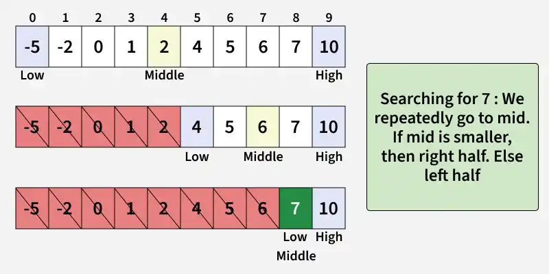

Algoritma Binary Search melakukan pencarian pada sebuah array dan mengembalikan index dari nilai yang dicari.

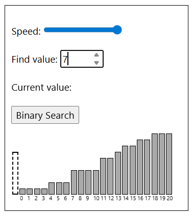

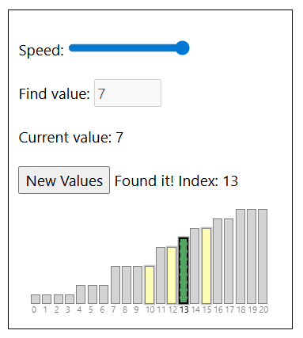

Jalankan simulasi untuk melihat bagaimana algoritma Binary Search bekerja.

Untuk melihat apa yang terjadi ketika sebuah nilai tidak ditemukan, coba cari nilai 5.

Binary Search jauh lebih cepat dibandingkan Linear Search, tetapi membutuhkan array yang sudah terurut agar dapat bekerja.

Algoritma Binary Search bekerja dengan memeriksa nilai di tengah array. Jika nilai target lebih kecil, maka nilai berikutnya yang diperiksa adalah nilai di tengah bagian kiri array. Cara pencarian seperti ini membuat area pencarian selalu menjadi setengah dari area sebelumnya, dan itulah alasan mengapa algoritma Binary Search sangat cepat.

Proses pembagian area pencarian ini terus berlangsung sampai nilai target ditemukan atau sampai area pencarian menjadi kosong.

#### Syarat Binary Search

Sebelum menggunakan Binary Search, data harus:

- Sudah terurut (sorted)
- Bisa ascending maupun descending

Contoh data terurut:

```
[2, 4, 6, 8, 10, 12]
```

Cara Kerja

1. Periksa nilai di tengah array.
2. Jika nilai target lebih kecil, cari pada bagian kiri array. Jika nilai target lebih besar, cari pada bagian kanan array.
3. Ulangi langkah 1 dan 2 pada bagian array yang sudah dipersempit sampai nilai target ditemukan atau area pencarian kosong.
4. Jika nilai ditemukan, kembalikan index nilai target. Jika nilai target tidak ditemukan, kembalikan -1.

#### Conditions to Apply Binary Search Algorithm in a Data Structure

- Struktur data harus dalam keadaan terurut (sorted).
- Akses ke setiap elemen dalam struktur data harus memerlukan waktu konstan (constant time).

### Binary Search Algorithm

- Bagi ruang pencarian menjadi dua bagian dengan mencari index tengah (mid).
- Bandingkan nilai tengah ruang pencarian dengan key.
- Jika key ditemukan di tengah, proses dihentikan.
- Jika key tidak ditemukan di tengah, tentukan bagian mana yang akan digunakan sebagai ruang pencarian berikutnya.
  - Jika key lebih kecil dari nilai tengah, gunakan bagian kiri untuk pencarian berikutnya.
  - Jika key lebih besar dari nilai tengah, gunakan bagian kanan untuk pencarian berikutnya.
- Proses ini terus dilakukan sampai key ditemukan atau seluruh ruang pencarian habis.

#### How does Binary Search Algorithm work?

Untuk memahami cara kerja Binary Search, perhatikan ilustrasi berikut.

Misalkan terdapat array: arr[] = {2, 5, 8, 12, 16, 23, 38, 56, 72, 91}, and the target = 23.

[figure not shown]

[figure not shown]

[figure not shown]

[figure not shown]

### Manual Run Through

Mari mencoba melakukan pencarian secara manual agar lebih memahami bagaimana Binary Search bekerja sebelum mengimplementasikannya menggunakan bahasa pemrograman. Kita akan mencari nilai 11.

Step 1

Kita mulai dengan sebuah array.

```
[2, 3, 7, 7, 11, 15, 25]
```

Step 2

Nilai di tengah array pada index 3, apakah nilainya sama dengan 11?

```
[2, 3, 7, 7, 11, 15, 25]
```

Step 3

7 lebih kecil dari 11, sehingga kita harus mencari 11 di sebelah kanan index 3. Nilai di sebelah kanan index 3 adalah [11, 15, 25]. Nilai berikutnya yang diperiksa adalah nilai tengah yaitu 15, pada index 5.

```
[2, 3, 7, 7, 11, 15, 25]
```

Step 4

15 lebih besar dari 11, sehingga kita harus mencari di sebelah kiri index 5. Kita sudah memeriksa index 0-3, jadi hanya index 4 yang tersisa untuk diperiksa.

```
[2, 3, 7, 7, 11, 15, 25]
```

Kita menemukannya!

Nilai 11 ditemukan pada index 4.

Mengembalikan posisi index 4.

Binary Search selesai.

Jalankan simulasi di bawah ini untuk melihat langkah-langkah di atas dalam bentuk animasi:

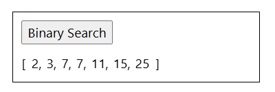

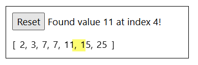

### Manual Run Through: Apa yang Terjadi?

Pada awalnya, algoritma memiliki dua variabel yaitu "left" dan "right".

"left" bernilai 0 dan mewakili index nilai pertama pada array, sedangkan "right" bernilai 6 dan mewakili index nilai terakhir pada array.

$(left+right)/2=(0+6)/2=3$ adalah indeks pertama yang digunakan untuk memeriksa apakah nilai tengah (7) sama dengan nilai target (11).

Karena 7 lebih kecil dari nilai target 11, maka pada loop berikutnya area pencarian harus dibatasi ke bagian kanan nilai tengah, yaitu [11, 15, 25] pada index 4-6.

Untuk mempersempit area pencarian dan menemukan nilai tengah baru, "left" diperbarui menjadi index 4, sedangkan "right" tetap 6. Nilai 4 dan 6 sekarang menjadi index awal dan akhir dari area pencarian baru. Nilai tengah baru dihitung menggunakan: $(left+right)/2=(4+6)/2=10/2=5$

Nilai tengah baru pada index 5 diperiksa. Nilai 15 lebih besar dari 11, sehingga jika target 11 ada di array maka harus berada di sebelah kiri index 5. Area pencarian baru dibuat dengan memperbarui "right" dari 6 menjadi 4. Sekarang "left" dan "right" sama-sama bernilai 4. Nilai tengah dihitung lagi: $(left+right)/2=(4+4)/2=4$, Karena hanya index 4 yang tersisa untuk diperiksa, maka target 11 ditemukan pada index 4, sehingga index 4 dikembalikan.

Secara umum, beginilah cara algoritma Binary Search terus membagi dua area pencarian sampai nilai target ditemukan.

Jika nilai target ditemukan, maka index dari nilai target dikembalikan. Jika tidak ditemukan, maka -1 dikembalikan.

### Ciri-Ciri Binary Search

1. Data Harus Terurut

   Binary Search tidak dapat digunakan pada data acak.
2. Membagi Data Menjadi Dua

   Pencarian dilakukan dengan membagi data.
3. Lebih Cepat

   Lebih efisien dibanding pencarian linear.
4. Menggunakan Indeks Tengah

   Fokus utama Binary Search adalah elemen tengah.

### Struktur Dasar Binary Search

Binary Search terdiri dari:

- Menentukan indeks kiri dan kanan
- Menghitung indeks tengah
- Membandingkan nilai tengah
- Mempersempit area pencarian

### Binary Search Implementation

Binary Search dapat diimplementasikan dengan dua cara berikut:

- Iterative Binary Search Algorithm
- Recursive Binary Search Algorithm

Untuk mengimplementasikan algoritma Binary Search, kita membutuhkan:

1. Sebuah array berisi nilai yang akan dicari.
2. Sebuah nilai target yang ingin dicari.
3. Sebuah loop yang berjalan selama index kiri (left) lebih kecil atau sama dengan index kanan (right).
4. Sebuah if-statement yang membandingkan nilai tengah dengan nilai target, lalu mengembalikan index jika nilai target ditemukan.
5. Sebuah if-statement yang memeriksa apakah nilai target lebih kecil atau lebih besar dari nilai tengah, lalu memperbarui variabel "left" atau "right" untuk mempersempit area pencarian.
6. Setelah loop selesai, kembalikan -1 karena pada titik tersebut kita tahu bahwa nilai target tidak ditemukan.

Kode hasil implementasi Binary Search terlihat seperti berikut.

##### Example Iterative Binary Search Algorithm:

```python
def binarySearch(arr, targetVal):
    left = 0
    right = len(arr) - 1

    while left <= right:
        mid = (left + right) // 2

        if arr[mid] == targetVal:
            return mid

        if arr[mid] < targetVal:
            left = mid + 1
        else:
            right = mid - 1

    return -1

myArray = [1, 3, 5, 7, 9, 11, 13, 15, 17, 19]
myTarget = 15

result = binarySearch(myArray, myTarget)

if result != -1:
    print("Value", myTarget, "found at index", result)
else:
    print("Target not found in array.")
```

```
Value 15 found at index 7
```

implementasi yang lain

```python
def binarySearch(arr, x):
    low = 0
    high = len(arr) - 1
    while low <= high:

        mid = low + (high - low) // 2

        # Check if x is present at mid
        if arr[mid] == x:
            return mid

        # If x is greater, ignore left half
        elif arr[mid] < x:
            low = mid + 1

        # If x is smaller, ignore right half
        else:
            high = mid - 1

    # If we reach here, then the element
    # was not present
    return -1

if __name__ == '__main__':
    arr = [2, 3, 4, 10, 40]
    x = 10

    result = binarySearch(arr, x)
    if result != -1:
        print(f"Element {x} is present at index, {result}")
    else:
        print("Element is not present in array")
```

```
Element 10 is present at index, 3
```

##### Example Recursive Binary Search Algorithm:

```python
def binarySearch(arr, low, high, x):

    # Check base case
    if high >= low:

        mid = low + (high - low) // 2

        # If element is present at the middle itself
        if arr[mid] == x:
            return mid

        # If element is smaller than mid, then it
        # can only be present in left subarray
        elif arr[mid] > x:
            return binarySearch(arr, low, mid-1, x)

        # Else the element can only be present
        # in right subarray
        else:
            return binarySearch(arr, mid + 1, high, x)

    # Element is not present in the array
    else:
        return -1

if __name__ == '__main__':
    arr = [2, 3, 4, 10, 40]
    x = 10

    result = binarySearch(arr, 0, len(arr)-1, x)

    if result != -1:
        print(f"Element {x} is present at index, {result}")
    else:
        print("Element is not present in array")
```

```
Element 10 is present at index, 3
```

### Binary Search Time Complexity

1. Best Case

   Jika data langsung ditemukan di tengah:

   O(1)
2. Average Case

   O(log n)
3. Worst Case

   O(log n)

Binary Search sangat cepat untuk data besar.

Setiap kali Binary Search memeriksa sebuah nilai baru untuk melihat apakah nilai tersebut adalah target, area pencarian akan dibagi menjadi setengah.

Hal ini berarti bahkan pada kondisi terburuk ketika Binary Search tidak dapat menemukan nilai target, algoritma tetap hanya membutuhkan log$_2 n$ kali perbandingan untuk menelusuri array terurut yang berisi n nilai.

Maka time complexity untuk Binary Search adalah $O($log$_2 n)$

### Applications

- Searching in sorted arrays: digunakan untuk melakukan pencarian pada array yang sudah terurut.
- Finding first/last occurrence or closest match: digunakan untuk mencari kemunculan pertama, kemunculan terakhir, atau nilai yang paling dekat dalam array terurut.
- Database indexing: digunakan pada B-trees dan struktur serupa untuk pencarian data database yang cepat.
- Debugging in version control: tools seperti git bisect menggunakan Binary Search untuk menemukan commit yang menyebabkan bug.
- Network routing & IP lookup: digunakan untuk menemukan routing entries secara efisien pada tabel yang diurutkan berdasarkan rentang alamat.
- File systems & libraries: digunakan untuk pencarian cepat pada direktori terurut atau symbol table.
- Gaming/graphics: digunakan pada collision detection atau ray tracing menggunakan data spasial yang sudah terurut.
- Machine learning tuning: digunakan untuk pencarian hyperparameter secara efisien, seperti learning rate atau threshold.
- Optimization problems & competitive programming: digunakan untuk menyelesaikan masalah boundary-value dengan mempersempit ruang pencarian.
- Advanced data structures: digunakan pada Binary Search Tree, self-balancing BST, dan fractional cascading yang bergantung pada logika pencarian.